# Лабораторная работа №3

Настройка DHCP-сервера

Устинова В. В.

Российский университет дружбы народов, Москва, Россия

19 cентября 2026

# Информация

## Докладчик

- Устинова Виктория Вадимовна
- студент НПИбд-01-24
- Российский университет дружбы народов

## Цель работы

Приобретение практических навыков по установке и конфигурированию DHCP-сервера

## Задание

1. Установите на виртуальной машине server DHCP-сервер (см. раздел 3.4.1).
2. Настройте виртуальную машину server в качестве DHCP-сервера для виртуальной внутренней сети (см. раздел 3.4.2).
3. Проверьте корректность работы DHCP-сервера в виртуальной внутренней сети путём запуска виртуальной машины client и применения соответствующих утилит диагностики (см. раздел 3.4.3).
4. Настройте обновление DNS-зоны при появлении в виртуальной внутренней сети новых узлов (см. раздел 3.4.4).
5. Проверьте корректность работы DHCP-сервера и обновления DNS-зоны в виртуаль- ной внутренней сети путём запуска виртуальной машины client и применения соответствующих утилит диагностики (см. раздел 3.4.5).
6. Напишите скрипт для Vagrant, фиксирующий действия по установке и настройке DHCP-сервера во внутреннем окружении виртуальной машины server. Соответ- ствующим образом внести изменения в Vagrantfile (см. раздел 3.4.6).

## Настройка domain-name и domain-search.

Откройте файл /etc/kea/kea-dhcp4.conf на редактирование. В этом файле: замените шаблон для domain-name

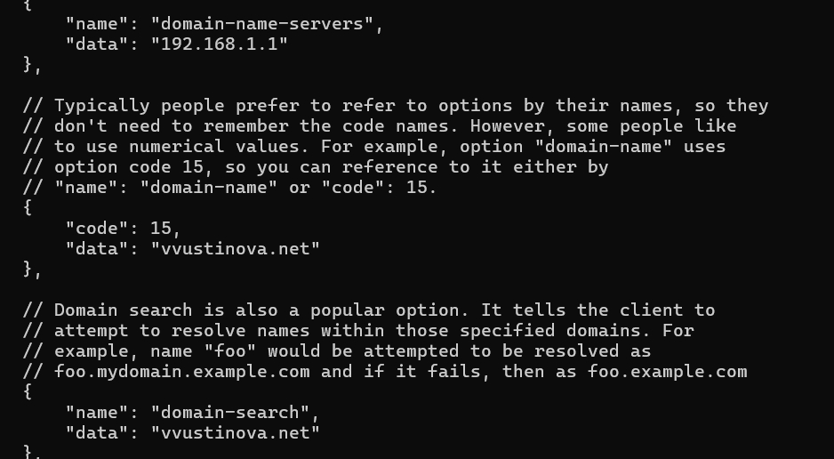

В файле указываем опции domain-name-servers с адресами 192.168.1.1 и указываем vvustinova.net

## Настройка подсети DHCP.

На базе одного из примеров задать собственную конфигурацию dhcp-сети: адрес подсети 192.168.1.0/24, диапазон адресов для распределения клиентам 192.168.1.30–192.168.1.199.

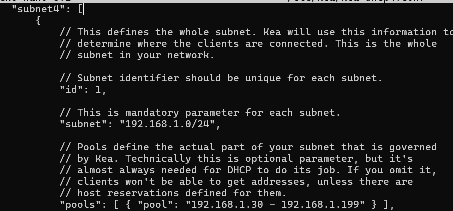

В блоке subnet4 заданы id 1, subnet 192.168.1.0/24 и pools с диапазоном адресов.

## Проверка конфигурации и автозапуск DHCP.

Проверить правильность конфигурационного файла командой kea-dhcp4 -t /etc/kea/kea-dhcp4.conf, перезагрузить конфигурацию dhcpd и разрешить загрузку DHCP-сервера при запуске.

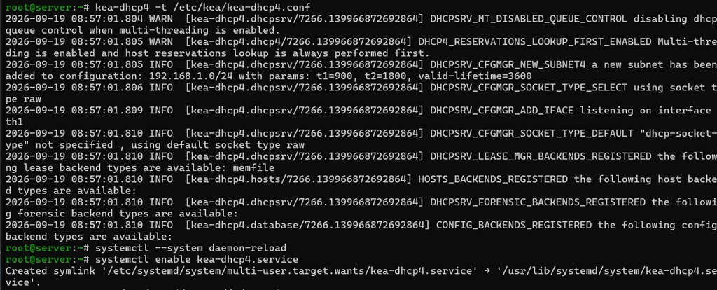

Проверка конфигурации прошла успешно, служба kea-dhcp4 включена в автозапуск.

## Добавление записи в прямую зону.

Добавить запись для DHCP-сервера в конце файла прямой DNS-зоны /var/named/master/fz/vvustinova.net: dhcp A 192.1681.

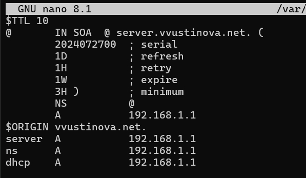

В файле прямой зоны добавлена A-запись dhcp с адресом 192.168.1.1.

## Добавление записи в обратную зону.

Добавить запись для DHCP-сервера в конце файла обратной зоны /var/named/master/rz/192.168. 1 PTR dhcp.vvustinovanet.

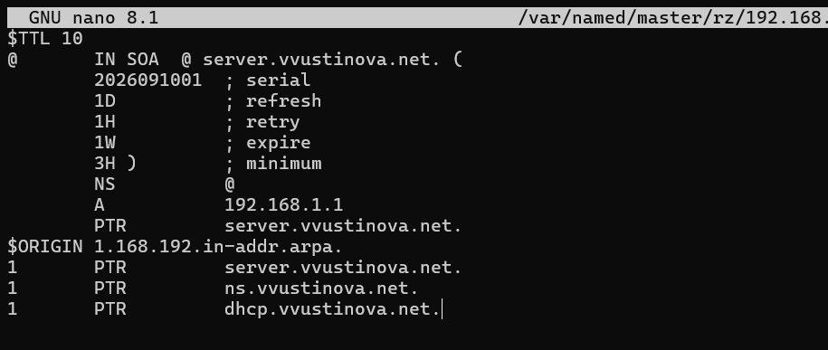

В файле обратной зоны добавлены PTR-записи для server, ns и dhcp

## Проверка имени DHCP-сервера.

Перезапустить named и проверить, что можно обратиться к DHCP-серверу по имени командой ping dhcp.vvustinovanet.

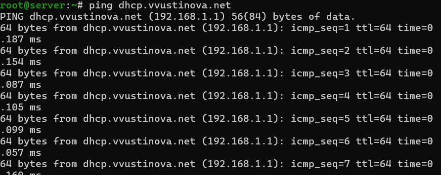

Пинг до dhcp.vvustinova.net успешно проходит, адрес 192.168.1.1.

## Настройка межсетевого экрана для DHCP.

Внести изменения в настройки межсетевого экрана узла server, разрешив работу с DHCP.

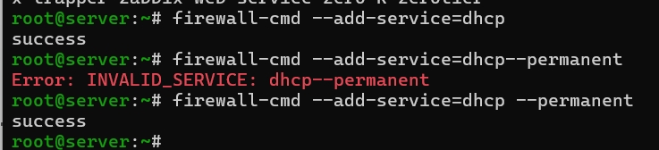

Выполнены команды firewall-cmd –add-service=dhcp и с флагом –permanent.

## Мониторинг системных сообщений.

В дополнительном терминале запустить мониторинг происходящих в системе процессов в реальном времени командой tail -f /var/log/messages.

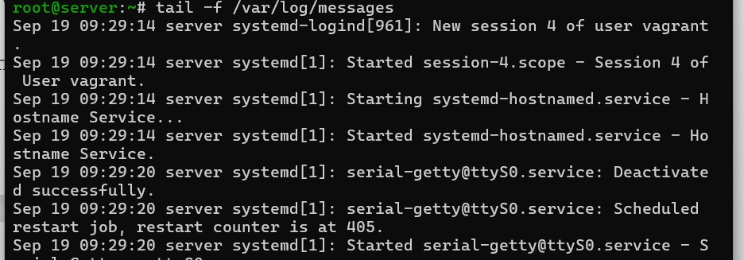

В логе видны записи о запуске systemd-hostnamed и serial-getty.

## Скрипт маршрутизации клиента.

Создать файл 01-routing.sh в каталоге provision/client, который изменяет настройки NetworkManager так, чтобы весь трафик на клиенте шёл по умолчанию через интерфейс eth1

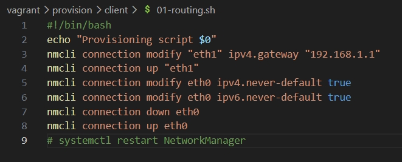

В скрипте прописаны команды nmcli для настройки шлюза и отключения default-маршрута на eth0.

## Подключение скрипта в Vagrantfile.

В Vagrantfile подключить скрипт 01-routing.sh в разделе конфигурации для клиента.

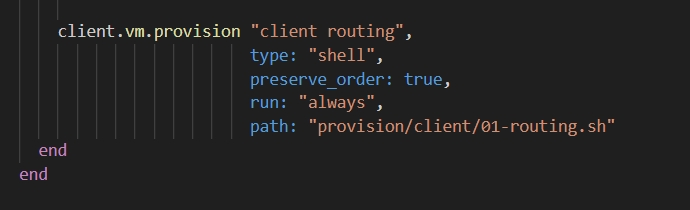

В Vagrantfile добавлен provision «client routing» с путём к скрипту.

## Применение настроек клиента.

Зафиксировать внесённые изменения для внутренних настроек виртуальной машины client и запустить её командой vagrant up client -provision

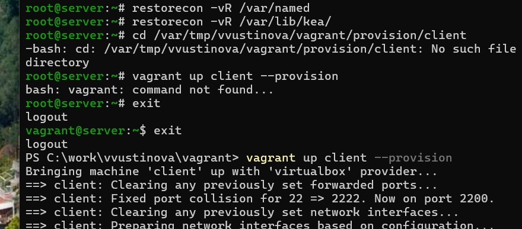

Выполнен restorecon, затем запуск клиента с провижинингом.

## Просмотр выданных адресов.

На машине server посмотреть список выданных адресов командой cat /var/lib/kea/kea-leases4.csv и прокомментировать информацию.

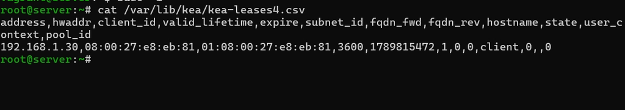

В файле аренды видна выдача адреса 192.168.1.30 клиенту с MAC-адресом 08:00:27:e8:eb:81.

## Проверка интерфейсов клиента.

Bойти в систему виртуальной машины client под своим пользователем и ввести ifconfig для просмотра информации об интерфейсах.

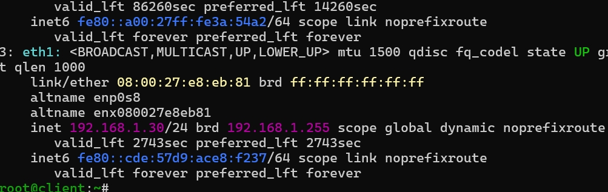

Интерфейс eth1 получил адрес 192.168.1.30/24, выданный DHCP-сервером.

## Создание ключа TSIG.

Создать ключ на сервере с Bind9 для обновления DNS-зоны: tsig-keygen

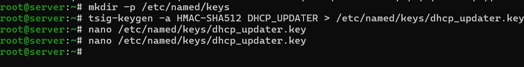

Создан каталог keys и сгенерирован ключ dhcp_updater.key.

## Настройка update-policy в зоне.

В файле /etc/named/vvustinova.net разрешить обновление зоны, прописав update-policy с grant DHCP_UPDATE для прямых и обратных зон

[figure not shown]

В зонах vvustinova.net и 1.168.192.in-addr.arpa добавлены политики обновления.

## Подключение ключа в named.conf.

Подключить ключ в файле /etc/named.conf через директиву include и указать listen-on с any.

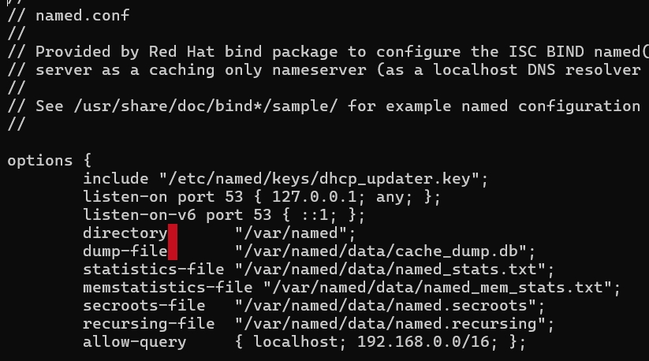

В named.conf добавлен include ключа, listen-on port 53 с 127.0.0.1 и any.

## Формирование ключа для Kea.

Сформировать ключ для Kea в файле /etc/kea/tsig-keys.json, указав имя DHCP_UPDATE, алгоритм hmac-sha512 и секрет

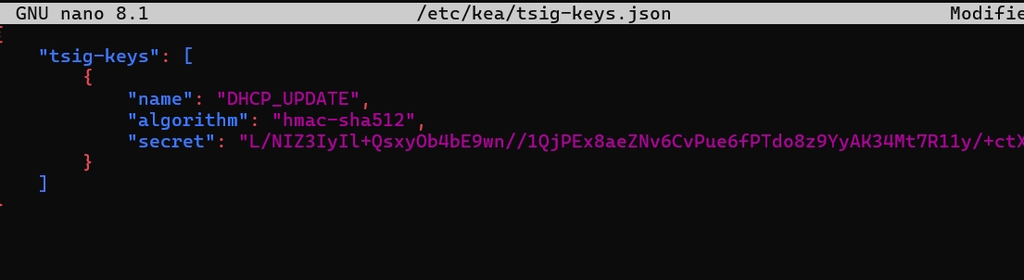

В файле tsig-keys.json прописан ключ DHCP_UPDATE.

## Настройка kea-dhcp-ddns.conf.

Настроить файл /etc/kea/kea-dhcp-ddns.conf: указать ip-address 1270.0.1, port 53001, control-socket, forward-ddns и reverse-ddns.

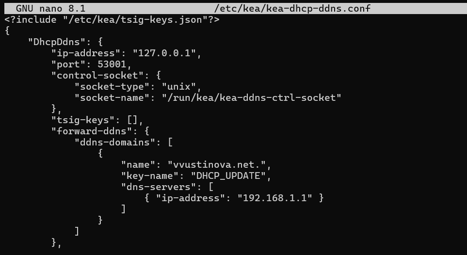

В конфигурации DDNS заданы forward-ddns для vvustinova.net и reverse-ddns для 1.168.192.in-addr.arpa.

## Проверка конфигурации DDNS.

Проверить файл на наличие возможных синтаксических ошибок командой kea-dhcp-ddns -t /etc/kea/kea-dhcp-ddns.conf

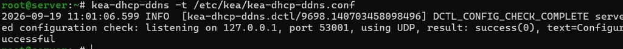

Проверка конфигурации kea-dhcp-ddns прошла успешно.

## Запуск службы DDNS.

Запустить службу ddns командой systemctl enable -now kea-dhcp-ddns.service и проверить статус работы службы.

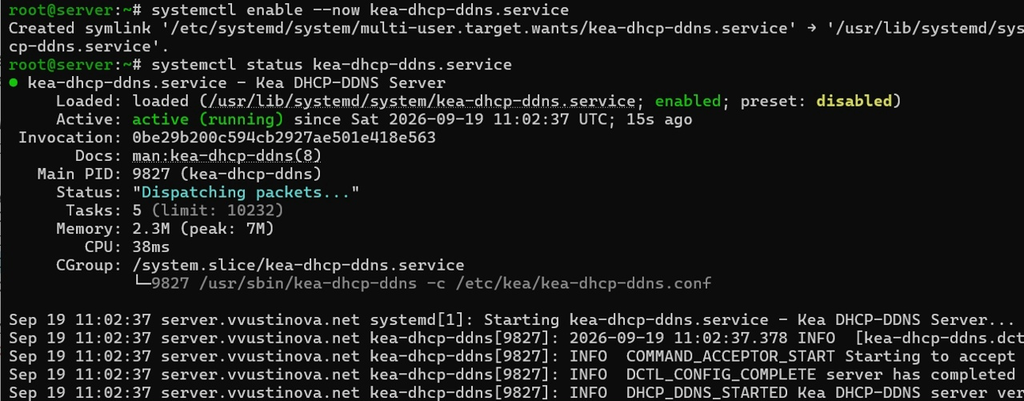

Служба kea-dhcp-ddns активна и работает.

## Настройка dhcp-ddns в kea-dhcp4.conf.

Bнести изменения в конфигурационный файл /etc/kea/kea-dhcp4.conf, добавив в него разрешение на динамическое обновление DNS-записей с локального узла прямой и обратной зон

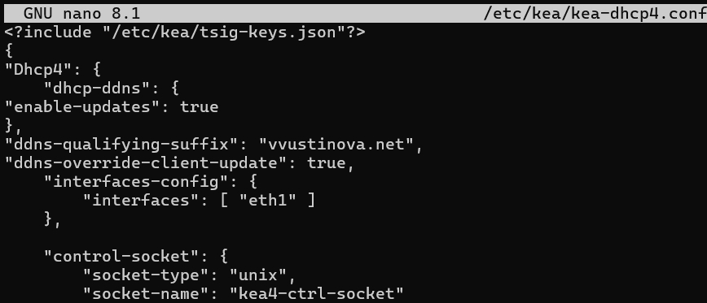

В блоке Dhcp4 добавлен dhcp-ddns с enable-updates true и ddns-qualifying-suffix vvustinova.net.

## Повторная проверка конфигурации DHCP.

Проверить файл на наличие возможных синтаксических ошибок командой kea-dhcp4 -t /etc/kea/kea-dhcp4.conf.

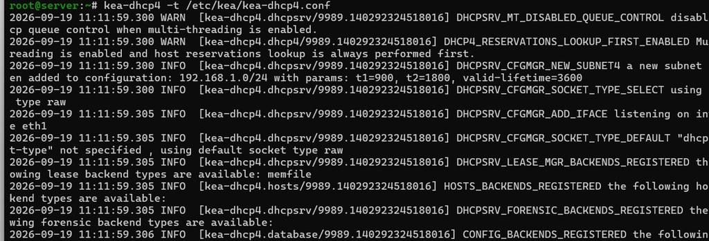

Проверка конфигурации kea-dhcp4 прошла успешно.

## Перезапуск DHCP-сервера.

Перезапустить DHCP-сервер и проверить статус работы командой systemctl status kea-dhcp4.service.

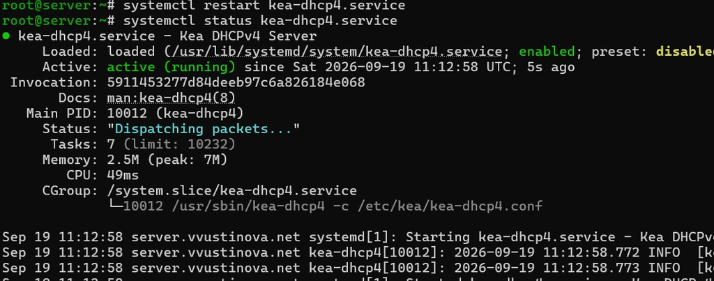

Служба kea-dhcp4 перезапущена и активна.

## Проверка tsig-keys в DDNS.

Убедиться, что в файле kea-dhcp-ddns.conf корректно прописан блок tsig-keys с ключом DHCP_UPDATE и forward-ddns для домена vvustinova.net.

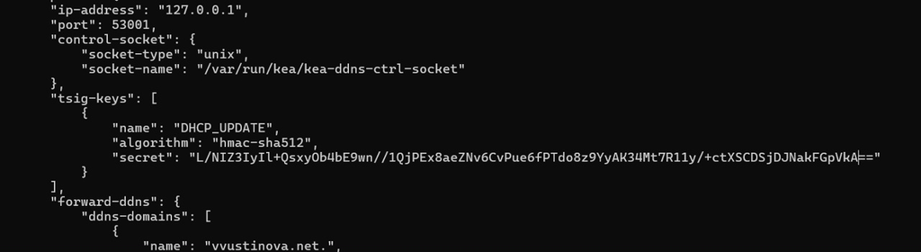

В файле видны ip-address, port, control-socket и tsig-keys.

## Проверка DNS-записи клиента.

На машине client переполучить адрес командами nmcli connection down eth1 и nmcli connection up eth1, затем с помощью утилиты dig убедиться в наличии DNS-записи о клиенте в прямой DNS-зоне.

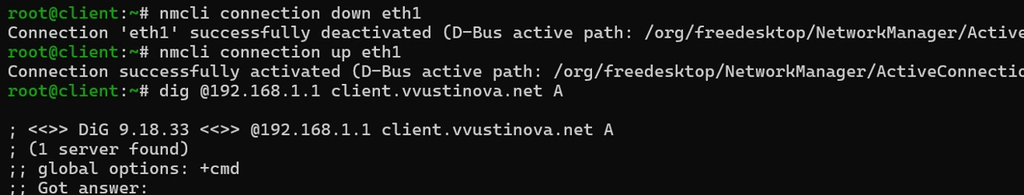

Выполнен запрос dig @192.168.1.1 client.vvustinova.net, получен ответ.

## Копирование конфигурационных файлов.

На виртуальной машине server перейти в каталог /vagrant/provision/server/, создать в нём каталог dhcp и поместить туда конфигурационные файлы DHCP. Заменить конфигурационные файлы DNS-сервера.

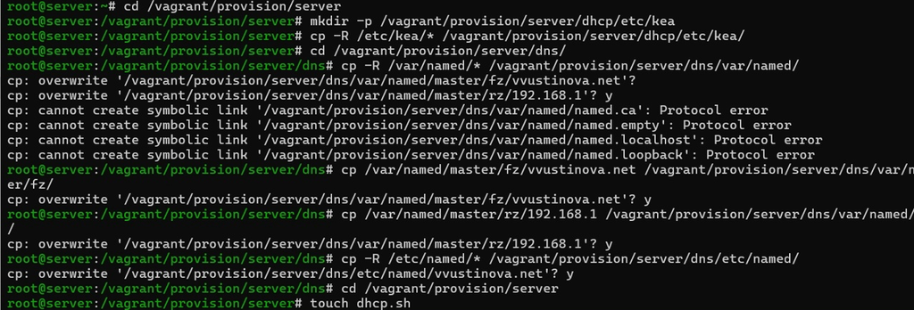

Выполнено копирование файлов kea и named в каталог provision.

## Скрипт dhcp.sh.

В каталоге /vagrant/provision/server создать исполняемый файл dhcp.sh, который повторяет действия по установке и настройке DHCP-сервера.

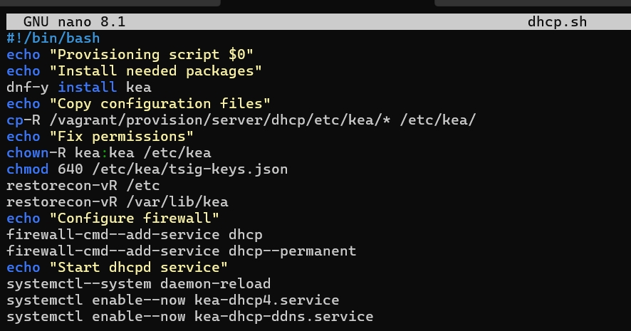

В скрипте прописаны установка kea, копирование конфигураций, права, firewall и запуск служб.

## Подключение provision в Vagrantfile.

Для отработки созданного скрипта во время загрузки виртуальной машины server добавить в Vagrantfile в разделе конфигурации для сервера provision «server dhcp».

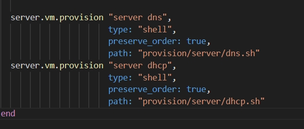

В Vagrantfile добавлены provision «server dns» и «server dhcp» с путями к скриптам.

## Применение настроек через Vagrant.

Применить изменения командой vagrant reload server -provision для перезагрузки сервера с применением скриптов настройки.

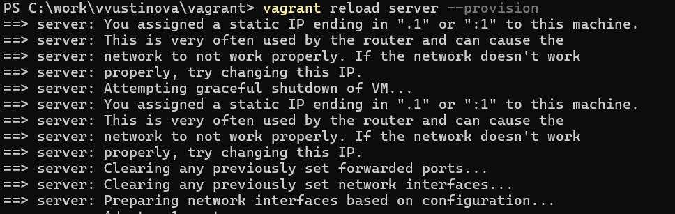

Выполнен vagrant reload server –provision, настройки применяются.

## Выводы

В ходе работы были приобретены практические навыки по установке и конфигурированию DHCP-сервера Kea. Освоены настройка подсети, диапазона адресов, шлюза и DNS-сервера, а также выдача адресов клиентам. Настроено динамическое обновление DNS-зоны при появлении новых узлов с использованием ключей TSIG. Проверена корректность работы DHCP-сервера и обновления DNS-записей. Создан скрипт автоматической настройки DHCP-сервера для Vagrant.